# Ford GoBike System Data

### Data wrangling and cleaning

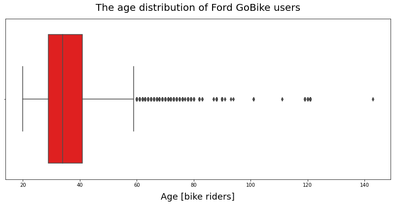

- as we see here we can remove user with more than 60 as the distrubition of users between 20 and 60 years

# structure of our data

### finaly our data have a structure as 169992 rows and 15 columns with some main features of interest like

- user_type
- member_gender
- age
- Average riding duration
- Weekly day distrubition

# visualization

# what type of users use our system most?

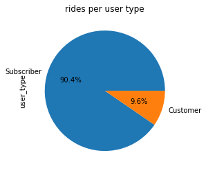

- as we can see here the majorty of users are subscriber

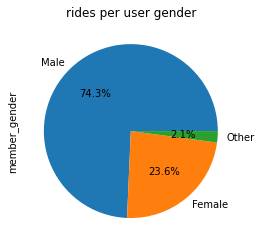

- as we can see here the male users tend to use bikes more

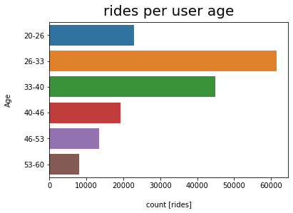

- as we see here that youth tend to ride bikes more

# how rides distrbute over day's hours?

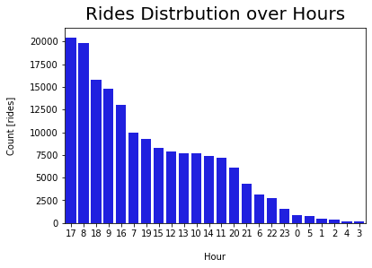

# how ride distrbute over days?

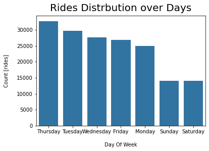

- here we can conclude that our users using bikes for Commuting not for leisure as we can see the least rides in vacation

### what Average trip duration per user type?

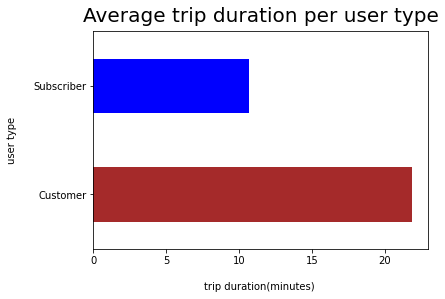

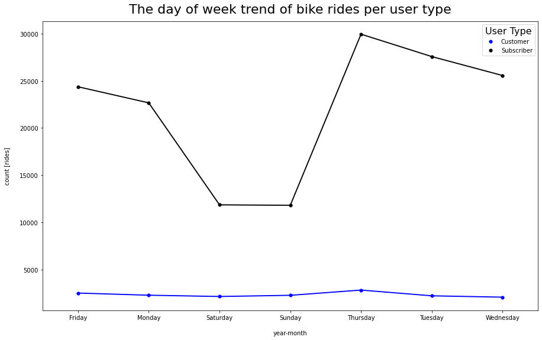

- we can conclude that subscriper ride decrease in weekend days and great increase in work days while customers has slightly increase in work days

# Main purpose bike rides for subscribers and customers (20~40 years age group)

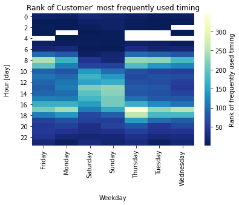

- here we conclude that in weekend days customers most frequently used this service around 10am ~ 4 pm where in work days from 7am ~ 9am and 4pm ~ 6 pm

[figure not shown]

- here we conclude that in weekend days Subscriber in work days from 8am ~ 9am and 4pm ~ 7 pm
- relative to customer heatmap subscriber rearly use the bike system in weekends

# Conclusion

[output not shown]